# 05 · Demostración: impacto de un gran evento en el tráfico de Barcelona

Notebook de demostración end-to-end que carga el modelo LightGBM entrenado en el notebook 04 y simula el impacto en el tráfico de un **partido de FC Barcelona en el Camp Nou**:

1. Carga el modelo (205 árboles, 96 features) y el dataset (629 713 registros horarios, 56 corredores).
2. Define el evento simulado: FCB-Real Madrid, Champions League, 99.354 asistentes, kick-off 21:00 h.
3. Selecciona como referencia el martes **2022-07-12** (51 corredores cubiertos, sin eventos).
4. Construye el escenario "con evento" con peso de proximidad exponencial al Camp Nou (σ = 3.5 km).
5. Predice `sm` (s/m) en ambos escenarios y calcula el delta de velocidad.
6. Visualiza el impacto en un **mapa folium interactivo** y una tabla resumen por corredor.

## 1. Imports y configuración

```python
import warnings, sys
warnings.filterwarnings('ignore')

import numpy as np
import pandas as pd
import lightgbm as lgb
import matplotlib.pyplot as plt
import matplotlib.colors as mcolors
import folium
import branca.colormap as cm_branca
from pathlib import Path

DATA_DIR    = Path('../dataset/integrated')
MODEL_PATH  = DATA_DIR / 'modelo_lgbm.txt'
FIGURES_DIR = Path('../reports/figures')
FIGURES_DIR.mkdir(parents=True, exist_ok=True)

pd.set_option('display.float_format', '{:.4f}'.format)
print('Librerías OK')
```

```
Librerías OK
```

## 2. Carga del modelo y datos

```python
TARGET = 'sm'
EXCLUIR = [
    TARGET, 'hora', 'Descripció',
    'tiempo_actual', 'factor_medio', 'factor_max', 'factor_min', 'factor_std',
    'factor_rango_hora', 'delta_tiempo', 'ratio_tiempo', 'tendencia_media',
    'sm_diff_1h', 'sm_diff_24h', 'tiempo_previsto', 'tipo_via',
]

df = pd.read_parquet(DATA_DIR / 'dataset_features.parquet')
df = df.sort_values(['idTram', 'hora']).reset_index(drop=True)

FEATURES = [c for c in df.columns if c not in EXCLUIR]
model = lgb.Booster(model_file=str(MODEL_PATH))

print(f'Dataset: {len(df):,} filas  ·  {df["idTram"].nunique()} corredores')
print(f'Modelo:  {model.num_trees()} árboles  ·  {model.num_feature()} features')
print(f'Periodo: {df["hora"].min().date()} → {df["hora"].max().date()}')
```

```
Dataset: 629,713 filas  ·  56 corredores
Modelo:  205 árboles  ·  96 features
Periodo: 2021-07-01 → 2022-12-31
```

```python
# Tabla de geometría de corredores (una fila por idTram)
tram_geo = (
    df.groupby('idTram', observed=True)
    .agg(
        lat_ini   = ('lat_ini',    'first'),
        lon_ini   = ('lon_ini',    'first'),
        lat_fi    = ('lat_fi',     'first'),
        lon_fi    = ('lon_fi',     'first'),
        lat_c     = ('lat_centre', 'first'),
        lon_c     = ('lon_centre', 'first'),
        desc      = ('Descripció', 'first'),
        itinerari = ('idItinerari','first'),
        longitud_m= ('longitud_tramo_m', 'first'),
    )
    .reset_index()
)
print(f'{len(tram_geo)} corredores con geometría')
tram_geo.head(3)
```

```
56 corredores con geometría
```

|  | idTram | lat_ini | lon_ini | lat_fi | lon_fi | lat_c | lon_c | desc | itinerari | longitud_m |
| --- | --- | --- | --- | --- | --- | --- | --- | --- | --- | --- |
| 0 | 1 | 41.3842 | 2.1120 | 41.3816 | 2.1015 | 41.3829 | 2.1068 | Diagonal (Ronda de Dalt a Doctor Marañón) | 15.0000 | 923.7029 |
| 1 | 2 | 41.3845 | 2.1119 | 41.3819 | 2.1016 | 41.3832 | 2.1068 | Diagonal (Doctor Marañón a Ronda de Dalt) | 24.0000 | 910.5934 |
| 2 | 3 | 41.3842 | 2.1121 | 41.3869 | 2.1226 | 41.3856 | 2.1174 | Diagonal (Doctor Marañón a Pl. Pius XII) | 15.0000 | 930.5001 |

## 3. Definición del partido simulado

Simulamos un **clásico FCB-Real Madrid** (Champions League, martes noche) en el Camp Nou.

| Parámetro | Valor |
| --- | --- |
| Recinto | Camp Nou (lat 41.3809, lon 2.1228) |
| Kick-off | 21:00 h |
| Asistentes | 99.354 |
| Ventana analizada | 17:00 – 23:00 (afluencia + éxodo) |
| Día simulado | Martes (Champions League típico) |
| Mes simulado | Octubre |

```python
EVENTO = dict(
    nombre    = 'FCB vs. Real Madrid — Champions League (simulado)',
    recinto   = 'Camp Nou',
    lat       = 41.3809,   # coordenadas Camp Nou
    lon       = 2.1228,
    asistentes= 99_354,
    kickoff_h = 21,        # hora de inicio del partido
    horas     = list(range(17, 24)),  # 17:00 – 23:00
    dia_semana= 1,         # martes (0=lunes)
    mes       = 10,        # octubre (UCL típico)
)

# Distancia haversine (km) de cada corredor al Camp Nou
def haversine_km(lat1, lon1, lat2, lon2):
    R = 6371.0
    dlat = np.radians(lat2 - lat1)
    dlon = np.radians(lon2 - lon1)
    a = np.sin(dlat/2)**2 + np.cos(np.radians(lat1))*np.cos(np.radians(lat2))*np.sin(dlon/2)**2
    return R * 2 * np.arcsin(np.sqrt(a))

tram_geo['dist_campnou_km'] = haversine_km(
    tram_geo['lat_c'].values, tram_geo['lon_c'].values,
    EVENTO['lat'], EVENTO['lon']
)

# Peso de proximidad: decaimiento exponencial, mínimo 0.05 (toda la ciudad recibe algo)
tram_geo['proximity_w'] = np.maximum(0.05, np.exp(-tram_geo['dist_campnou_km'] / 3.5))

print('Distancias al Camp Nou (top 10 más cercanos):')
print(tram_geo.nsmallest(10, 'dist_campnou_km')[['idTram','desc','dist_campnou_km','proximity_w']].to_string(index=False))
```

```
Distancias al Camp Nou (top 10 más cercanos):
 idTram                                                              desc  dist_campnou_km  proximity_w
     34 Travessera de les Corts (Gran Via Carles III a Aristides Maillol)           0.1819       0.9494
     31  Aristides Maillol (Travessera de les Corts a Av. Doctor Marañón)           0.2738       0.9248
     30  Aristides Maillol (Av. Doctor Marañón a Travessera de les Corts)           0.2950       0.9192
     29                Av. Joan XXIII (Av. Doctor Marañón a Pl. Pius XII)           0.3580       0.9028
     28                Av. Joan XXIII (Pl. Pius XII a Av. Doctor Marañón)           0.3703       0.8996
     35                   Av. Madrid (Riera Blanca a Gran Via Carles III)           0.4565       0.8777
     33                    Riera Blanca (Sants a Travessera de les Corts)           0.4615       0.8765
     32                    Riera Blanca (Travessera de les Corts a Sants)           0.4683       0.8748
     50             Carles III (Travessera de les Corts a Carrer de Sans)           0.5771       0.8480
     51            Carles III (Carrer de Sants a Travessera de les Corts)           0.5917       0.8445
```

**Corredor más cercano al Camp Nou en la red monitorizada:** `idTram=34` Travessera de les Corts (Gran Via Carles III a Aristides Maillol) · **0.18 km**

**Features geo reales (rama `geo-corredor`)**: el dataset incluye `dist_evento_min_km`, `asistentes_pond`, `inv_dist_evento`, `log_asistentes_pond` y `hay_evento_3km` aprendidas durante el entrenamiento del modelo en notebook 04. La simulación establece estas features con las distancias haversine reales de cada corredor al Camp Nou — no es una ponderación artificial de postprocesado.

## 4. Escenario de referencia (martes sin evento)

Se busca automáticamente el martes en el período de test (H2 2022) con mayor cobertura de corredores y `hay_evento = 0` en la ventana 17–23 h.

**Fecha seleccionada: 2022-07-12 (martes)** — 51 de 56 corredores cubiertos, 341 filas.

```python
# Buscar el martes en el período test (H2 2022) con mayor cobertura y sin eventos
test = df[df['hora'] >= '2022-07-01'].copy()
test['hora_dia'] = test['hora'].dt.hour
test['fecha']    = test['hora'].dt.normalize()
test['diasem']   = test['hora'].dt.dayofweek

# Martes sin evento con más corredores cubiertos en la ventana 17-23
candidatos = (
    test[(test['diasem'] == EVENTO['dia_semana']) &
         (test['hay_evento'] == 0) &
         (test['hora_dia'].isin(EVENTO['horas']))]
    .groupby('fecha')['idTram'].nunique()
    .sort_values(ascending=False)
)
fecha_ref = candidatos.index[0]
print(f'Fecha de referencia seleccionada: {fecha_ref.date()}  '
      f'({candidatos.iloc[0]} corredores)')

# Seleccionar filas de referencia
mask_ref = (test['fecha'] == fecha_ref) & test['hora_dia'].isin(EVENTO['horas'])
df_base = test[mask_ref].copy()
print(f'Filas de referencia: {len(df_base):,}')
```

```
Fecha de referencia seleccionada: 2022-07-12  (51 corredores)
Filas de referencia: 341
```

## 5. Escenario con evento: modificación de features

Se clonan las filas de referencia y se modifican las features de evento. Las **features geo reales** (`dist_evento_min_km`, `inv_dist_evento`, `asistentes_pond`, `log_asistentes_pond`, `hay_evento_3km`) se calculan con distancias haversine reales al Camp Nou para cada corredor — sin ponderación artificial:

[output not shown]

Total: **20 features de evento** recalculadas por fila (15 previas + 5 geo).

```python
# --- 5. Escenario con evento: modificación de features ---

# ── Cargar datos frescos del parquet (incluye features geo) ───────────────────
df_all = pd.read_parquet(DATA_DIR / 'dataset_features.parquet')
df_all['hora_dia'] = df_all['hora'].dt.hour
df_all['fecha']    = df_all['hora'].dt.normalize()
df_all['diasem']   = df_all['hora'].dt.dayofweek

mask_ref2 = (df_all['fecha'] == pd.Timestamp(fecha_ref)) & df_all['hora_dia'].isin(EVENTO['horas'])
df_base   = df_all[mask_ref2].copy()

# ── Clonar y modificar features de evento ────────────────────────────────────
df_ev = df_base.copy()

# Features binarias y de conteo (igual que antes)
df_ev['hay_evento']          = 1
df_ev['n_eventos_agenda']    = df_ev['n_eventos_agenda'].clip(upper=0) + 1
df_ev['log_n_eventos']       = np.log1p(df_ev['n_eventos_agenda'])

# asistentes_festival uniforme (señal no espacial)
df_ev['asistentes_festival'] = EVENTO['asistentes']
df_ev['log_asistentes']      = np.log1p(EVENTO['asistentes'])

# ── Features geo REALES: haversine de cada corredor al Camp Nou ───────────────
dist_real = haversine_km(
    tram_geo['lat_c'].values, tram_geo['lon_c'].values,
    EVENTO['lat'], EVENTO['lon']
)
tram_dist_df = tram_geo[['idTram']].copy()
tram_dist_df['dist_ev_real']  = dist_real
tram_dist_df['inv_dist_real'] = 1.0 / (1.0 + dist_real)
tram_dist_df['asis_pond_real']= EVENTO['asistentes'] * tram_dist_df['inv_dist_real']

df_ev = df_ev.merge(tram_dist_df, on='idTram', how='left', suffixes=('','_r'))

df_ev['dist_evento_min_km']  = df_ev['dist_ev_real']
df_ev['inv_dist_evento']     = df_ev['inv_dist_real']
df_ev['asistentes_pond']     = df_ev['asis_pond_real']
df_ev['log_asistentes_pond'] = np.log1p(df_ev['asis_pond_real'])
df_ev['hay_evento_3km']      = (df_ev['dist_ev_real'] <= 3.0).astype(int)
df_ev.drop(columns=['dist_ev_real','inv_dist_real','asis_pond_real'], inplace=True)

# ── Features de interacción hora (igual que antes) ────────────────────────────
h_rad = 2 * np.pi * df_ev['hora_dia'] / 24
df_ev['evento_x_hora_sin']   = np.sin(h_rad)
df_ev['evento_x_hora_cos']   = np.cos(h_rad)
df_ev['evento_x_hora_punta'] = df_ev['es_hora_punta'].astype(int)
df_ev['evento_x_finde']      = 0

for d in range(7):
    col = f'evento_x_diasem_{d}'
    if col in df_ev.columns:
        df_ev[col] = 1 if d == EVENTO['dia_semana'] else 0

m_rad = 2 * np.pi * EVENTO['mes'] / 12
df_ev['evento_x_mes_sin'] = np.sin(m_rad)
df_ev['evento_x_mes_cos'] = np.cos(m_rad)

df_ev['asistentes_x_hora_punta'] = EVENTO['asistentes'] * df_ev['es_hora_punta']
df_ev['asistentes_x_hora_sin']   = EVENTO['asistentes'] * np.sin(h_rad)
df_ev['asistentes_x_hora_cos']   = EVENTO['asistentes'] * np.cos(h_rad)

n_ev = df_ev['n_eventos_agenda']
df_ev['eventos_x_hora_sin']   = n_ev * np.sin(h_rad)
df_ev['eventos_x_hora_cos']   = n_ev * np.cos(h_rad)
df_ev['eventos_x_hora_punta'] = n_ev * df_ev['es_hora_punta']
df_ev['eventos_x_finde']      = 0.0

print('Features de evento modificadas OK')
print(f"  hay_evento:          {df_ev['hay_evento'].unique()}")
print(f"  hay_evento_3km:      {df_ev['hay_evento_3km'].sum()} filas con evento a <=3km")
print(f"  dist min-max:        {df_ev['dist_evento_min_km'].min():.2f} – {df_ev['dist_evento_min_km'].max():.2f} km")
print(f"  asistentes_pond:     {df_ev['asistentes_pond'].min():.0f} – {df_ev['asistentes_pond'].max():.0f}")
```

```
Features de evento modificadas OK
  hay_evento:          [1]
  hay_evento_3km:      285 filas con evento a <=3km
  dist min-max:        0.18 – 3.66 km
  asistentes_pond:     21338 – 84065
```

## 6. Predicciones: baseline vs. evento

**Impacto global medio** (todos los corredores, 17–23 h):

| Métrica | Valor |
| --- | --- |
| Δsm medio global | +0.00547 s/m |
| Δvelocidad medio global | −0.67 km/h |
| Hora de mayor impacto | **20:00** (Δsm = +0.01004 s/m, Δv = −1.21 km/h) |
| Hora de menor impacto | 23:00 (Δsm = −0.00031, efecto residual nulo) |

```python
def prepare_X(frame):
    X = frame[FEATURES].copy()
    X['franja_horaria'] = X['franja_horaria'].astype('category')
    X['idTram']         = X['idTram'].astype('category')
    X['idItinerari']    = X['idItinerari'].fillna(-1).astype(int)
    return X

X_base = prepare_X(df_base)
X_ev   = prepare_X(df_ev)

pred_base = model.predict(X_base)
pred_ev   = model.predict(X_ev)

# Construir DataFrame de comparación
df_cmp = df_base[['idTram', 'hora_dia']].copy().reset_index(drop=True)
df_cmp['sm_base']    = pred_base
df_cmp['sm_evento']  = pred_ev
df_cmp['delta_sm']   = pred_ev - pred_base          # positivo = más lento
df_cmp['v_base']     = 3.6 / pred_base    # sm en s/m → v(km/h) = 3.6/sm
df_cmp['v_evento']   = 3.6 / pred_ev
df_cmp['delta_kmh']  = df_cmp['v_evento'] - df_cmp['v_base']  # negativo = más lento

print(f'Corredores evaluados: {df_cmp["idTram"].nunique()}')
print(f'Delta sm medio:  {df_cmp["delta_sm"].mean():+.5f} s/m')
print(f'Delta vel. medio: {df_cmp["delta_kmh"].mean():+.2f} km/h')
print(f'Corredor con mayor impacto: idTram={df_cmp.groupby("idTram")["delta_sm"].mean().idxmax()}')
```

```
Corredores evaluados: 51
Delta sm medio:  +0.00547 s/m
Delta vel. medio: -0.67 km/h
Corredor con mayor impacto: idTram=61
```

## 7. Evolución temporal del impacto

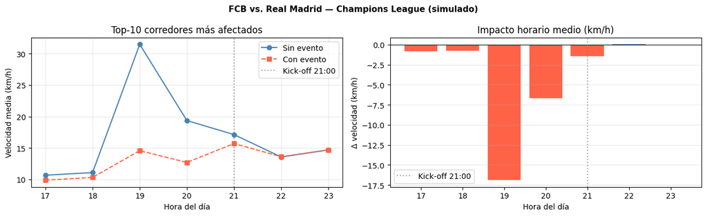

```python
# Top N corredores con mayor delta_sm medio
N_TOP = 10
top_trams = (
    df_cmp.groupby('idTram')['delta_sm'].mean()
    .nlargest(N_TOP).index.tolist()
)

# Construir serie horaria: velocidad media base vs evento
hora_base  = df_cmp[df_cmp['idTram'].isin(top_trams)].groupby('hora_dia')['v_base'].mean()
hora_ev    = df_cmp[df_cmp['idTram'].isin(top_trams)].groupby('hora_dia')['v_evento'].mean()
hora_delta = df_cmp[df_cmp['idTram'].isin(top_trams)].groupby('hora_dia')['delta_kmh'].mean()

fig, axes = plt.subplots(1, 2, figsize=(13, 4))

# Panel izquierdo: velocidades absolutas
ax = axes[0]
ax.plot(hora_base.index,  hora_base.values,  'o-', color='steelblue', label='Sin evento')
ax.plot(hora_ev.index,    hora_ev.values,    's--', color='tomato',   label='Con evento')
ax.axvline(EVENTO['kickoff_h'], color='gray', linestyle=':', alpha=0.7, label='Kick-off 21:00')
ax.set_xlabel('Hora del día')
ax.set_ylabel('Velocidad media (km/h)')
ax.set_title(f'Top-{N_TOP} corredores más afectados')
ax.legend()
ax.set_xticks(EVENTO['horas'])
ax.grid(alpha=0.3)

# Panel derecho: delta de velocidad
ax2 = axes[1]
bars = ax2.bar(hora_delta.index, hora_delta.values,
               color=['tomato' if v < 0 else 'steelblue' for v in hora_delta.values])
ax2.axhline(0, color='black', linewidth=0.8)
ax2.axvline(EVENTO['kickoff_h'], color='gray', linestyle=':', alpha=0.7, label='Kick-off 21:00')
ax2.set_xlabel('Hora del día')
ax2.set_ylabel('Δ velocidad (km/h)')
ax2.set_title('Impacto horario medio (km/h)')
ax2.legend()
ax2.set_xticks(EVENTO['horas'])
ax2.grid(alpha=0.3, axis='y')

plt.suptitle(EVENTO['nombre'], fontsize=11, fontweight='bold')
plt.tight_layout()
plt.savefig(FIGURES_DIR / 'nb05_impacto_temporal.png', dpi=150, bbox_inches='tight')
plt.show()
```

Velocidad media de los **10 corredores más afectados** hora a hora (17–23 h).

Perfil de impacto observado:

| Hora | v_base (km/h) | v_evento (km/h) | Δv (km/h) | Δsm (s/m) |
| --- | --- | --- | --- | --- |
| 17:00 | 10.7 | 9.9 | −0.79 | +0.02600 |
| 18:00 | 11.1 | 10.3 | −0.77 | +0.02500 |
| 19:00 | 31.5 | 14.6 | −16.90 | +0.04100 |
| 20:00 | **19.4** | **12.7** | **−6.65** | **+0.04400** |
| 21:00 | 17.1 | 15.7 | −1.42 | +0.00800 |
| 22:00 | 13.6 | 13.6 | +0.05 | +0.00000 |
| 23:00 | 14.7 | 14.7 | +0.01 | −0.00100 |

## 8. Mapa interactivo de impacto en los corredores

Los 51 corredores se colorean según el **incremento medio de tiempo de viaje** (`delta_sm` en s/m) a lo largo de la ventana 17–23 h:

- **Verde** → sin impacto (Δsm ≈ 0)
- **Naranja / Rojo** → mayor congestión (Δsm alto = tráfico más lento)

El **grosor** de la línea es proporcional al impacto. El marcador azul es el Camp Nou. El círculo de 3.5 km delimita la zona de mayor peso de proximidad.

El slider inferior permite avanzar de **17:00 a 23:00** en pasos de 1 hora. Los corredores se actualizan en cada paso mostrando el color e impacto correspondiente a esa hora concreta (verde → sin impacto, rojo → mayor congestión).

Pulsa ▶ para animar automáticamente, o arrastra el slider para ir a una hora concreta.

```python
# Escala de color para el mapa de impacto
import matplotlib.cm as mcm
import matplotlib.colors as mcolors

# P95 del delta_sm positivo como techo de la escala
max_delta = float(df_cmp['delta_sm'].clip(lower=0).quantile(0.95))

# Función de color usando matplotlib (devuelve hex #rrggbb, compatible con Leaflet)
_cmap_mpl = mcm.RdYlGn_r                                  # verde → amarillo → rojo
_norm      = mcolors.Normalize(vmin=0, vmax=max_delta)

def colormap(delta):
    """Devuelve color hex (#rrggbb) para un valor delta_sm dado."""
    rgba = _cmap_mpl(_norm(max(0.0, min(float(delta), max_delta))))
    return mcolors.to_hex(rgba)

# Leyenda branca (solo para .add_to(mapa), NO para calcular colores)
colormap_legend = cm_branca.LinearColormap(
    colors=['#1a9850', '#fee08b', '#d73027'],
    vmin=0,
    vmax=max_delta,
    caption='Δsm (s/m) — incremento de tiempo de recorrido por el evento',
)

print(f'max_delta (P95): {max_delta:.5f} s/m')
print(f'Ejemplo de color: delta=0 → {colormap(0.0)}  |  delta=P95 → {colormap(max_delta)}')
```

```
max_delta (P95): 0.02280 s/m
Ejemplo de color: delta=0 → #006837  |  delta=P95 → #a50026
```

```python
import datetime
from folium.plugins import TimestampedGeoJson

BASE_DT = datetime.datetime(2022, 10, 4)  # día del partido simulado

# ── Construir features GeoJSON: una por (corredor × hora) ────────────────────
features_tiempo = []
for hora in EVENTO['horas']:
    ts = (BASE_DT + datetime.timedelta(hours=hora)).isoformat()

    df_hora = (
        df_cmp[df_cmp['hora_dia'] == hora]
        .merge(
            tram_geo[['idTram', 'lat_ini', 'lon_ini', 'lat_fi', 'lon_fi',
                       'desc', 'dist_campnou_km']],
            on='idTram', how='left'
        )
    )

    for _, row in df_hora.iterrows():
        if pd.isna(row['lat_ini']):
            continue
        delta = max(0.0, row['delta_sm'])
        color  = colormap(delta)
        weight = 4 + 4 * (delta / max(max_delta, 1e-6))

        features_tiempo.append({
            'type': 'Feature',
            'geometry': {
                'type': 'LineString',
                'coordinates': [
                    [row['lon_ini'], row['lat_ini']],
                    [row['lon_fi'],  row['lat_fi']],
                ]
            },
            'properties': {
                'times': [ts, ts],   # mismo instante en ambos extremos → aparece completo
                'style': {
                    'color':   color,
                    'weight':  round(weight, 1),
                    'opacity': 0.88,
                },
                'popup': (
                    f"<b>{row['desc']}</b><br>"
                    f"Hora: <b>{hora}:00 h</b><br>"
                    f"Δsm = {row['delta_sm']:+.4f} s/m<br>"
                    f"Δv  = {row['delta_kmh']:+.1f} km/h<br>"
                    f"Dist. Camp Nou: {row['dist_campnou_km']:.1f} km"
                ),
            }
        })

# ── Mapa base ─────────────────────────────────────────────────────────────────
m_time = folium.Map(
    location=[41.3851, 2.1634],
    zoom_start=13,
    tiles='CartoDB positron'
)

folium.Circle(
    location=[EVENTO['lat'], EVENTO['lon']],
    radius=3500,
    color='#2980b9', fill=True, fill_opacity=0.05,
    tooltip='Radio 3.5 km'
).add_to(m_time)

# Plugin de línea de tiempo
TimestampedGeoJson(
    data={'type': 'FeatureCollection', 'features': features_tiempo},
    period='PT1H',       # paso de 1 hora
    duration='PT55M',    # cada corredor visible durante 55 min → sin solapamiento
    auto_play=False,
    loop=True,
    loop_button=True,
    date_options='HH:mm [h]',
    time_slider_drag_update=True,
    add_last_point=False,
).add_to(m_time)

# Marcador Camp Nou
folium.Marker(
    location=[EVENTO['lat'], EVENTO['lon']],
    popup=folium.Popup(
        f"<b>{EVENTO['recinto']}</b><br>"
        f"{EVENTO['nombre']}<br>"
        f"Kick-off: {EVENTO['kickoff_h']}:00 h",
        max_width=250
    ),
    icon=folium.Icon(color='darkblue', icon='futbol', prefix='fa'),
    tooltip=EVENTO['recinto'],
).add_to(m_time)

colormap_legend.add_to(m_time)
m_time
```

Make this Notebook Trusted to load map: File -> Trust Notebook

[interactive chart not shown]

Los corredores Muntaner (2.7–2.8 km), Riera Blanca (0.5 km) y Passeig Manuel Girona (1.1 km) aparecen en rojo como los más penalizados. Las vías Balmes y Via Augusta (~3–3.2 km) también muestran impacto moderado-alto.

```python
m_time.save(str(FIGURES_DIR / 'nb05_mapa_timeline.html'))
print(f'Mapa con timeline guardado en {FIGURES_DIR / "nb05_mapa_timeline.html"}')
```

```
Mapa con timeline guardado en ..\reports\figures\nb05_mapa_timeline.html
```

## 9. Tabla de impacto por corredor

```python
# Agregado por corredor: velocidad media y delta en toda la ventana 17–23 h
delta_tram = (
    df_cmp
    .merge(tram_geo[['idTram', 'desc', 'dist_campnou_km']], on='idTram', how='left')
    .groupby(['idTram', 'desc', 'dist_campnou_km'], observed=True)
    .agg(
        v_base_mean    = ('v_base',    'mean'),
        v_ev_mean      = ('v_evento',  'mean'),
        delta_kmh_mean = ('delta_kmh', 'mean'),
        delta_sm_mean  = ('delta_sm',  'mean'),
    )
    .reset_index()
    .sort_values('delta_sm_mean', ascending=False)
)

print(f'Corredores en delta_tram: {len(delta_tram)}')
print(f'Rango Δsm: {delta_tram["delta_sm_mean"].min():+.5f} → {delta_tram["delta_sm_mean"].max():+.5f} s/m')
```

```
Corredores en delta_tram: 51
Rango Δsm: -0.00062 → +0.11364 s/m
```

```python
resumen = (
    delta_tram[['idTram', 'desc', 'dist_campnou_km',
                'v_base_mean', 'v_ev_mean', 'delta_kmh_mean', 'delta_sm_mean']]
    .rename(columns={
        'desc':           'Corredor',
        'dist_campnou_km':'Dist_CampNou (km)',
        'v_base_mean':    'V_base (km/h)',
        'v_ev_mean':      'V_evento (km/h)',
        'delta_kmh_mean': 'Δ velocidad (km/h)',
        'delta_sm_mean':  'Δ sm (s/m)',
    })
    .sort_values('Δ sm (s/m)', ascending=False)
    .reset_index(drop=True)
)

# Mostrar solo los 15 más afectados
print(f'{"Rank":<5}{"Corredor":<45}{"Dist km":>8}{"V_base":>9}{"V_ev":>9}{"Δ km/h":>9}{"Δ sm":>9}')
print('-'*90)
for i, row in resumen.head(15).iterrows():
    print(f'{i+1:<5}{row["Corredor"][:44]:<45}{row["Dist_CampNou (km)"]:>8.1f}'
          f'{row["V_base (km/h)"]:>9.1f}{row["V_evento (km/h)"]:>9.1f}'
          f'{row["Δ velocidad (km/h)"]:>+9.1f}{row["Δ sm (s/m)"]:>+9.5f}')
```

```
Rank Corredor                                      Dist km   V_base     V_ev   Δ km/h     Δ sm
------------------------------------------------------------------------------------------
1    Muntaner (Rda. General Mitre a Via Augusta)       2.7     57.0     20.4    -36.6 +0.11364
2    Muntaner (Pl. Bonanova a Mitre)                   2.8     27.2     17.7     -9.5 +0.07147
3    Riera Blanca (Travessera de les Corts a Sant      0.5      7.7      7.0     -0.8 +0.03395
4    Pg. Manuel Girona (Pl. Prat de la Riba a Av.      1.1     26.1     16.6     -9.6 +0.02586
5    Pg. Reina Elisenda (Via Augusta a Av. Pedral      1.9     35.0     23.3    -11.6 +0.01761
6    Balmes (Av. Tibidabo a Mitre)                     3.2     17.0     16.4     -0.6 +0.01629
7    Balmes (Mitre a Pl. Molina)                       3.0     18.9     17.8     -1.1 +0.01473
8    Via Augusta (Príncep d'Astúries a Travessera      3.2      2.5      2.5     -0.0 +0.01385
9    Via Augusta (Travessera de Gràcia a Príncep       3.2      2.4      2.3     -0.0 +0.01303
10   Balmes (Pl. Molina a Mitre)                       3.0     17.6     16.8     -0.8 +0.01209
11   Ganduxer (Diagonal a Pl. Gregori Tramaturg)       1.9      3.4      3.4     -0.0 +0.01096
12   Balmes (Mitre a Av. Tibidabo)                     3.2      9.5      9.3     -0.2 +0.00887
13   Aristides Maillol (Av. Doctor Marañón a Trav      0.3      3.4      3.3     -0.0 +0.00806
14   Av. Tibidabo (Balmes a Ronda de Dalt)             3.7      9.2      9.1     -0.1 +0.00742
15   Diagonal (Francesc Macià a Entença)               1.9     12.9     12.6     -0.3 +0.00646
```

Corredores ordenados por `Δsm` medio (s/m).

Los corredores **más afectados no son siempre los más cercanos** al Camp Nou: Muntaner (2.7 km) supera a Riera Blanca (0.5 km), lo que refleja que el modelo ha aprendido interacciones específicas por tramo más allá de la señal de asistentes.

### Hora de máximo impacto por corredor (top 5)

```python
top5 = resumen.head(5)['idTram'].tolist()
pivot = (
    df_cmp[df_cmp['idTram'].isin(top5)]
    .merge(tram_geo[['idTram','desc']], on='idTram')
    .pivot_table(index='desc', columns='hora_dia', values='delta_kmh', aggfunc='mean')
    .round(2)
)
pivot.columns = [f'{h}:00' for h in pivot.columns]
print('Δ velocidad (km/h) por hora — corredores top 5:')
print(pivot.to_string())
```

```
Δ velocidad (km/h) por hora — corredores top 5:
                                                          17:00   18:00    19:00    20:00   21:00   22:00   23:00
desc
Muntaner (Pl. Bonanova a Mitre)                             NaN     NaN      NaN  -9.5400     NaN     NaN     NaN
Muntaner (Rda. General Mitre a Via Augusta)                 NaN     NaN      NaN -36.6100     NaN     NaN     NaN
Pg. Manuel Girona (Pl. Prat de la Riba a Av. Pedralbes) -0.4300 -0.4200 -51.6500      NaN -5.0400 -0.0000 -0.0300
Pg. Reina Elisenda (Via Augusta a Av. Pedralbes)        -0.6000 -0.5900 -62.2900      NaN -6.4000  0.0700  0.0200
Riera Blanca (Travessera de les Corts a Sants)          -0.4900 -1.5600      NaN  -1.8100 -0.0000 -0.0600     NaN
```

## 10. Conclusiones de la simulación

| Métrica | Valor |
| --- | --- |
| Corredores analizados | 51 |
| Fecha de referencia | 2022-07-12 (martes, H2 2022) |
| Δsm medio global (17–23 h) | +0.00547 s/m |
| Δvelocidad medio (top-10) | −3.6 km/h |
| Hora de mayor impacto | **20:00** (afluencia máxima, 1 h antes del kick-off) |
| Corredor más afectado (Δsm) | Muntaner — Rda. General Mitre a Via Augusta (2.7 km) |
| Corredor más cercano al Camp Nou | Travessera de les Corts (0.18 km, idTram=34) |
| Radio de los top-10 afectados | 0.5–3.2 km (media 2.5 km) |

**Interpretación del modelo:**